# Séries Temporelles : fiche TP4

Thomas Besnier, Wilfried Heyse

# Etude de processus stationnaires ARMA

Nous étudions la série chronologique disponible dans le fichier `AR.txt` contenant un processus AR.

```r
modele<-list(ar=(c(1,-1/4)))
n=500
x=arima.sim(modele,n)
write(as.vector(x), file = "AR.txt", ncolumns = 1)
```

1. Observer les auto-corrélations empiriques (partielles ou non). Retrouvez les indices sur le type de processus.

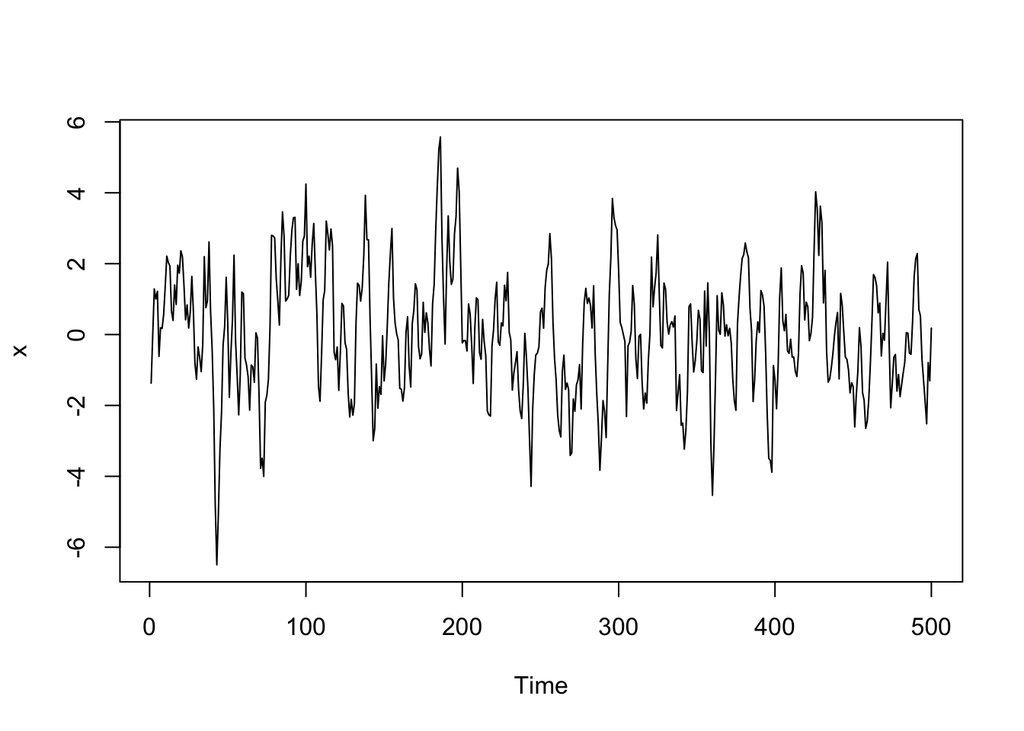

```r
plot(x)
```

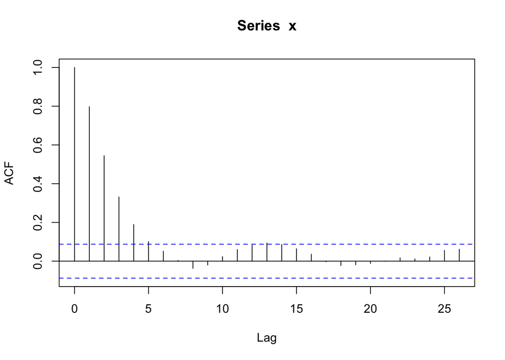

```r
acf(x)
```

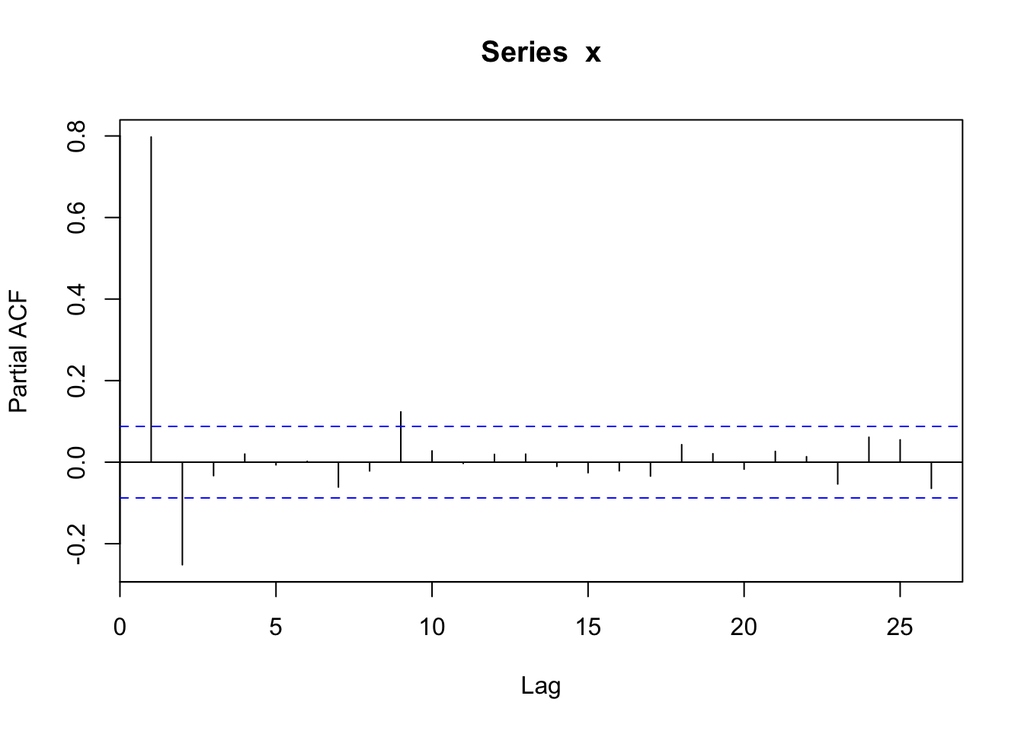

```r
pacf(x)
```

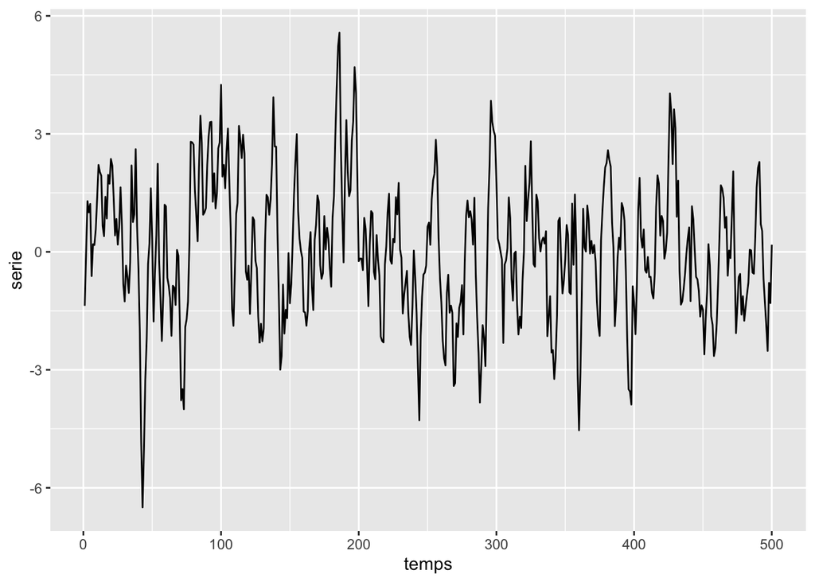

```r
data_serie <- data.frame(temps = 1:length(x), serie = x)
ggplot(data_serie, aes(x = temps, y = serie)) +
    geom_line()
```

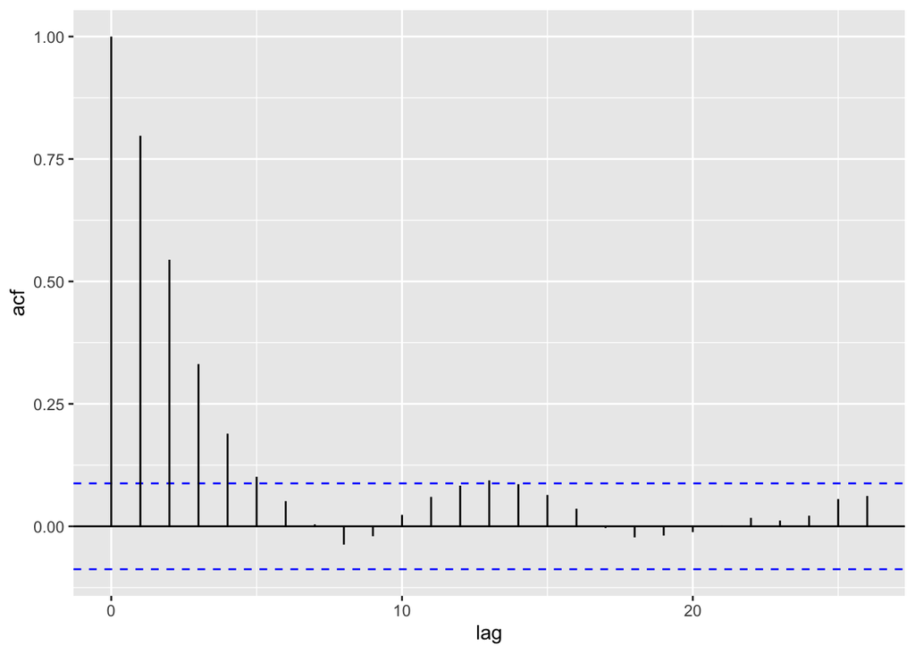

```r
conf.level <- 0.95
ciline <- qnorm((1 - conf.level)/2)/sqrt(length(data_serie$serie))
bacf <- acf(data_serie$serie, plot = FALSE)
bacfdf <- with(bacf, data.frame(lag, acf))

ggplot(data = bacfdf, aes(x = lag, y = acf)) +
       geom_hline(aes(yintercept = 0)) +
        geom_hline(aes(yintercept = -ciline), color = "blue", lty = 'dashed') +
        geom_hline(aes(yintercept = ciline), color = "blue", lty = 'dashed') +
       geom_segment(mapping = aes(xend = lag, yend = 0))
```

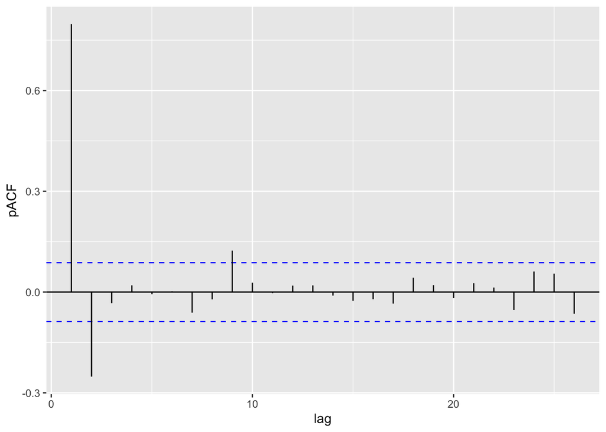

```r
conf.level <- 0.95
ciline <- qnorm((1 - conf.level)/2)/sqrt(length(data_serie$serie))
bacf <- pacf(data_serie$serie, plot = FALSE)
bacfdf <- with(bacf, data.frame(lag, acf))

ggplot(data = bacfdf, aes(x = lag, y = acf)) +
       geom_hline(aes(yintercept = 0)) +
        geom_hline(aes(yintercept = -ciline), color = "blue", lty = 'dashed') +
        geom_hline(aes(yintercept = ciline), color = "blue", lty = 'dashed') +
       geom_segment(mapping = aes(xend = lag, yend = 0)) +
  ylab("pACF")
```

Pour AR(2) -> ACF décroissante exponentiellement et pACF 2 pics différents de 0.

2. Estimez les coefficients du processus (on pourra utiliser la fonction `arima` sous R ou `ARIMA` disponible dans `statsmodels.tsa.arima.model` sous Python)

```r
modele <- arima(data_serie$serie, order = c(2,0,0))
modele$coef
```

```
##         ar1         ar2   intercept
##  1.00138951 -0.25553489  0.04265166
```

Le processus s’écrit donc $X_t = 1 X_{t-1} + -0.26 X_{t-2} + \epsilon_t$ avec $\epsilon_t$ un bruit blanc.

3. Pour le processus AR, sachant que les coefficients choisits pour simuler le processus étaient 1 et $-\frac{1}{4}$, le processus était-il bien stationnaire ?

Oui, le polynome caractériqtique associé est $A(z) = 1-1z^1-(-\frac{1}{4})z^2$ dont la racine, 2, est de module strictement supérieur à 1.

4. En vous basant sur l’analyse des résidus, la modélisations semble-t-elle fidèle aux données ?

```r
Box.test(modele$residuals, lag = 20)
```

```
##
##  Box-Pierce test
##
## data:  modele$residuals
## X-squared = 13.239, df = 20, p-value = 0.8669
```

On accepte $H_0$ donc on valide que les résidus sont un bruit blanc.

5. Effectuez le même travail sur les processus des fichiers `MA.txt` et `ARMA.txt`

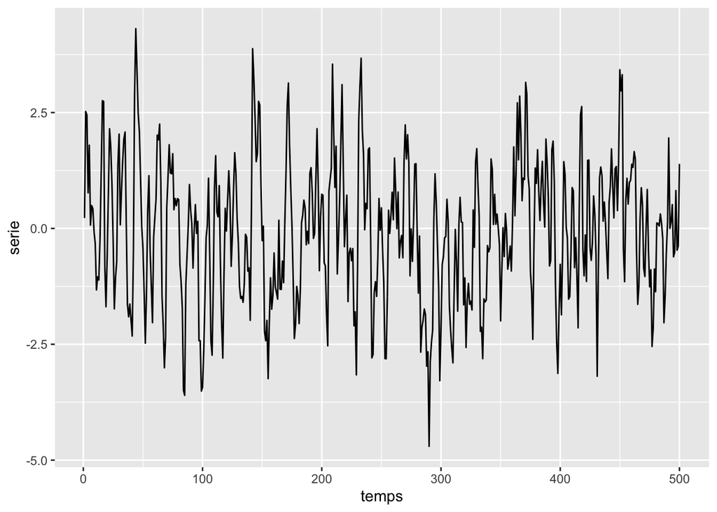

```r
modele<-list(ma=(c(1/1,1/2,1/3)))
x=arima.sim(modele,n)

write(as.vector(x), file = "MA.txt", ncolumns = 1)

data_serie <- data.frame(temps = 1:length(x), serie = x)
ggplot(data_serie, aes(x = temps, y = serie)) +
    geom_line()
```

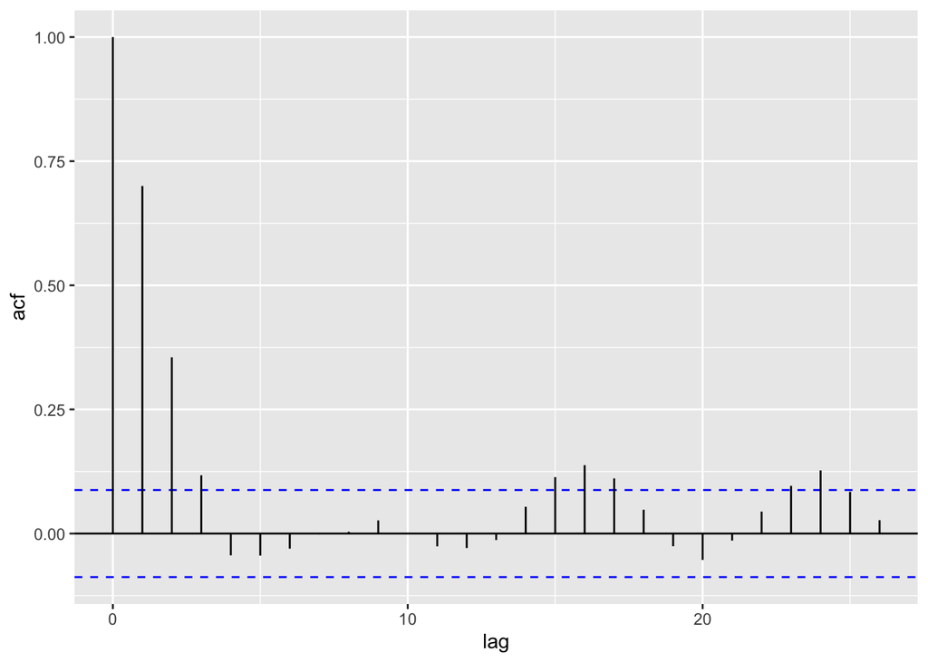

```r
conf.level <- 0.95
ciline <- qnorm((1 - conf.level)/2)/sqrt(length(data_serie$serie))
bacf <- acf(data_serie$serie, plot = FALSE)
bacfdf <- with(bacf, data.frame(lag, acf))

ggplot(data = bacfdf, aes(x = lag, y = acf)) +
       geom_hline(aes(yintercept = 0)) +
        geom_hline(aes(yintercept = -ciline), color = "blue", lty = 'dashed') +
        geom_hline(aes(yintercept = ciline), color = "blue", lty = 'dashed') +
       geom_segment(mapping = aes(xend = lag, yend = 0))
```

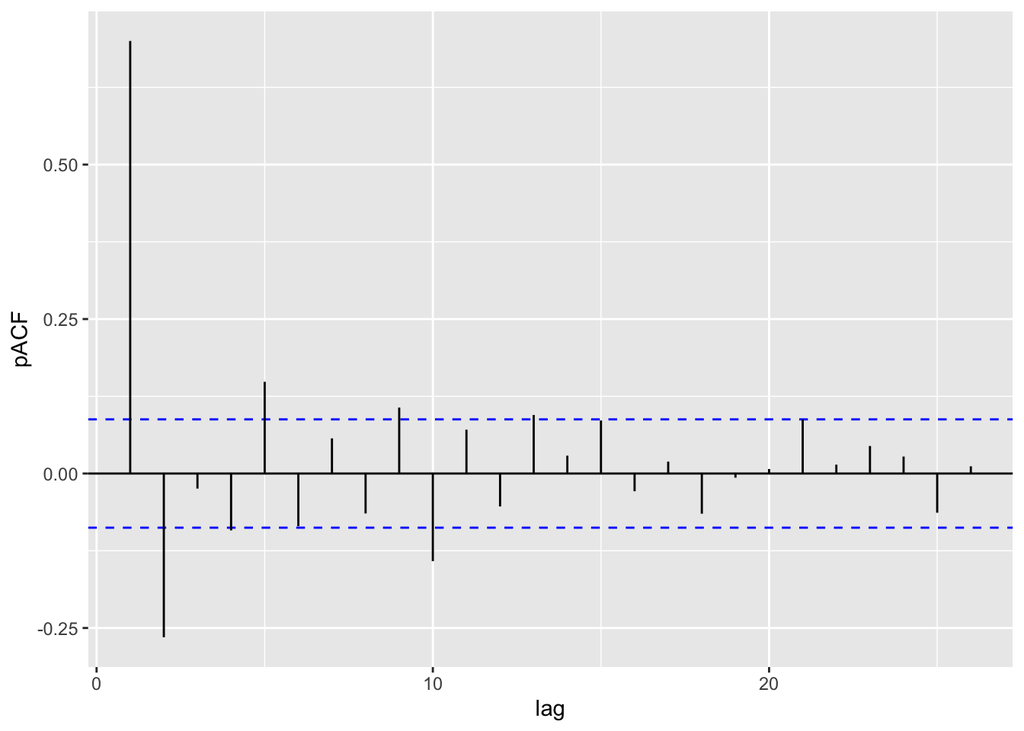

```r
conf.level <- 0.95
ciline <- qnorm((1 - conf.level)/2)/sqrt(length(data_serie$serie))
bacf <- pacf(data_serie$serie, plot = FALSE)
bacfdf <- with(bacf, data.frame(lag, acf))

ggplot(data = bacfdf, aes(x = lag, y = acf)) +
       geom_hline(aes(yintercept = 0)) +
        geom_hline(aes(yintercept = -ciline), color = "blue", lty = 'dashed') +
        geom_hline(aes(yintercept = ciline), color = "blue", lty = 'dashed') +
       geom_segment(mapping = aes(xend = lag, yend = 0)) +
  ylab("pACF")
```

Pour MA(3) -> pACF décroissante exponentiellement et ACF 3 pics différents de 0.

```r
modele <- arima(data_serie$serie, order = c(0,0,3))
modele$coef
```

```
##         ma1         ma2         ma3   intercept
##  0.97367977  0.53099602  0.40607106 -0.07231922
```

Le processus s’écrit donc $X_t = 0.97 \epsilon_{t-1} + 0.53 \epsilon_{t-2} + 0.41 \epsilon_{t-3} + \epsilon_t$ avec $\epsilon_t$ un bruit blanc.

```r
Box.test(modele$residuals, lag = 20)
```

```
##
##  Box-Pierce test
##
## data:  modele$residuals
## X-squared = 15.373, df = 20, p-value = 0.7547
```

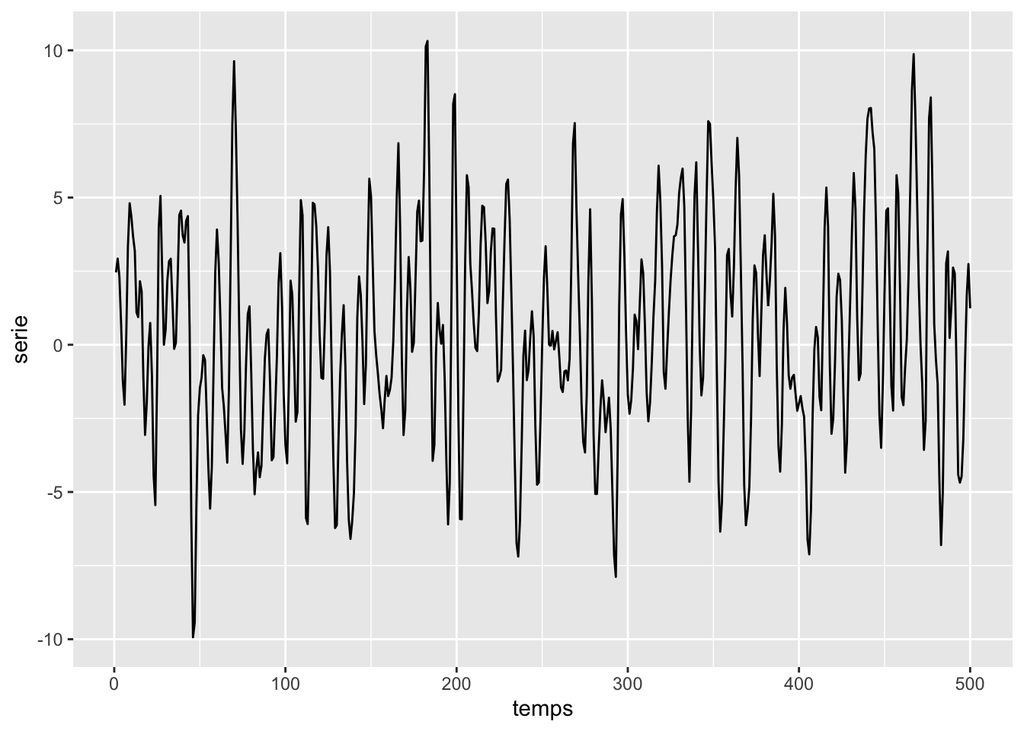

```r
modele<-list(ar = c(1,-1/2), ma=(c(1/1,1/2,1/3)))
x=arima.sim(modele,n)

write(as.vector(x), file = "ARMA.txt", ncolumns = 1)

data_serie <- data.frame(temps = 1:length(x), serie = x)
ggplot(data_serie, aes(x = temps, y = serie)) +
    geom_line()
```

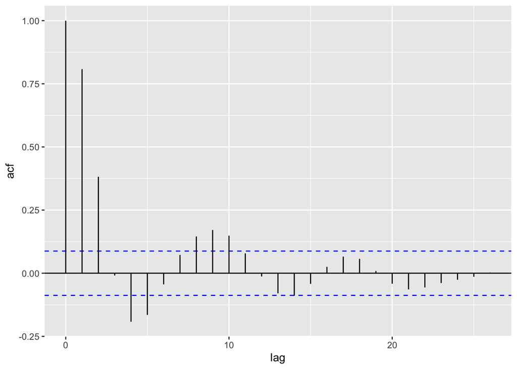

```r
conf.level <- 0.95
ciline <- qnorm((1 - conf.level)/2)/sqrt(length(data_serie$serie))
bacf <- acf(data_serie$serie, plot = FALSE)
bacfdf <- with(bacf, data.frame(lag, acf))

ggplot(data = bacfdf, aes(x = lag, y = acf)) +
       geom_hline(aes(yintercept = 0)) +
        geom_hline(aes(yintercept = -ciline), color = "blue", lty = 'dashed') +
        geom_hline(aes(yintercept = ciline), color = "blue", lty = 'dashed') +
       geom_segment(mapping = aes(xend = lag, yend = 0))
```

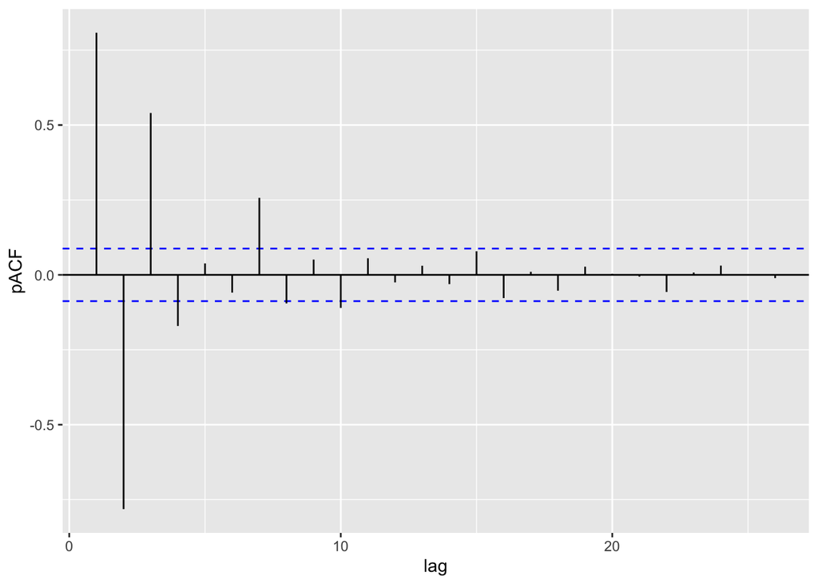

```r
conf.level <- 0.95
ciline <- qnorm((1 - conf.level)/2)/sqrt(length(data_serie$serie))
bacf <- pacf(data_serie$serie, plot = FALSE)
bacfdf <- with(bacf, data.frame(lag, acf))

ggplot(data = bacfdf, aes(x = lag, y = acf)) +
       geom_hline(aes(yintercept = 0)) +
        geom_hline(aes(yintercept = -ciline), color = "blue", lty = 'dashed') +
        geom_hline(aes(yintercept = ciline), color = "blue", lty = 'dashed') +
       geom_segment(mapping = aes(xend = lag, yend = 0)) +
  ylab("pACF")
```

Pour ARMA(2,3) -> ACF 3-2 pic différent de 0 et ACF 2-3 pic différent de 0. (En pratique les graphes ne sont pas très parlant) Si doutes -> estimer plusieurs modèles et minimiser l’AIC.

```r
modele <- arima(data_serie$serie, order = c(2,0,3))
modele$coef
```

```
##        ar1        ar2        ma1        ma2        ma3  intercept
##  0.9008973 -0.4894176  1.1648041  0.7367224  0.4752407  0.4075509
```

Le processus s’écrit donc $X_t = 0.9 X_{t-1} + -0.49 X_{t-2} + 1.16 \epsilon_{t-1} + 0.74 \epsilon_{t-2} + 0.48 \epsilon_{t-3} + \epsilon_t$ avec $\epsilon_t$ un bruit blanc.

```r
Box.test(modele$residuals, lag = 20)
```

```
##
##  Box-Pierce test
##
## data:  modele$residuals
## X-squared = 10.888, df = 20, p-value = 0.9491
```

# Prédiction d’un processus

```r
modele<-list(ar = c(1,-1/2), ma=(c(1/1,1/2,1/3)))
n <- 300
x=arima.sim(modele,n) + 0.5*1:n
write(as.vector(x), file = "Exercice2.txt", ncolumns = 1)
```

1. Ce processus vous semble-t-il modélisable par un processus ARMA ?

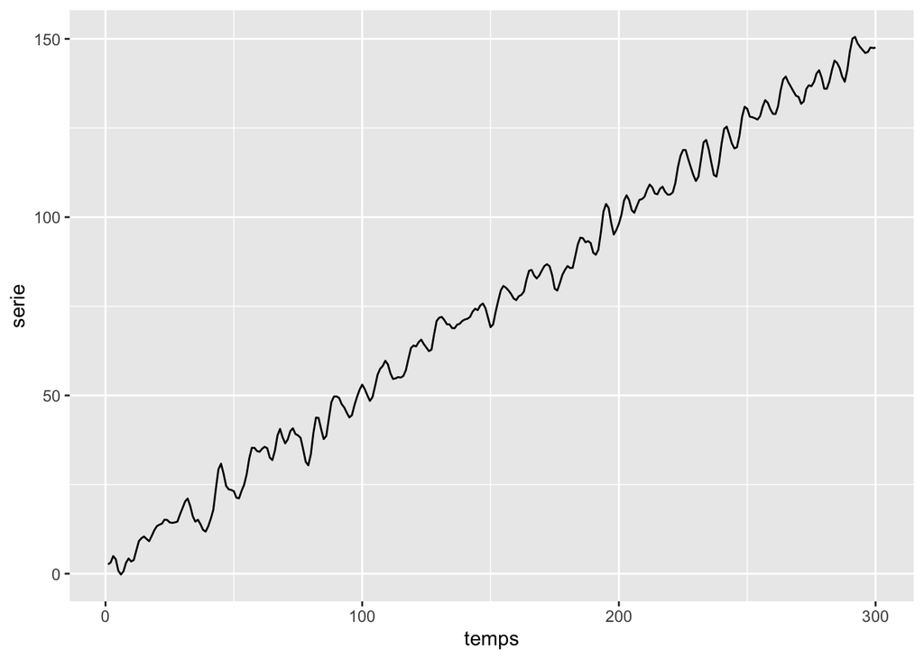

```r
data_serie <- data.frame(temps = 1:length(x), serie = x)
ggplot(data_serie, aes(x = temps, y = serie)) +
    geom_line()
```

Non, le processus est clairement non-stationnaire.

2. On travaille désormais avec la série obtenue avec la méthode des différences à la série. Combien de fois faut-il appliquer la méthode ici ?

Une seule fois car tendance linéaire.

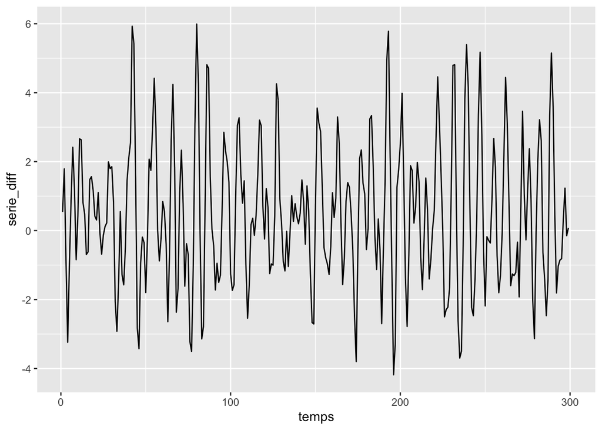

```r
x1=diff(data_serie$serie, lag=1, difference=1)

data_serie$serie_diff <- c(x1,NA)

ggplot(data_serie, aes(x = temps, y = serie_diff)) +
    geom_line()
```

3. En observant les auto-corrélations empiriques et auto-corrélations partielles empiriques, proposer des modèles AR(p), MA(q) ou ARMA(p,q) d’ordre faible pour modéliser cette série.

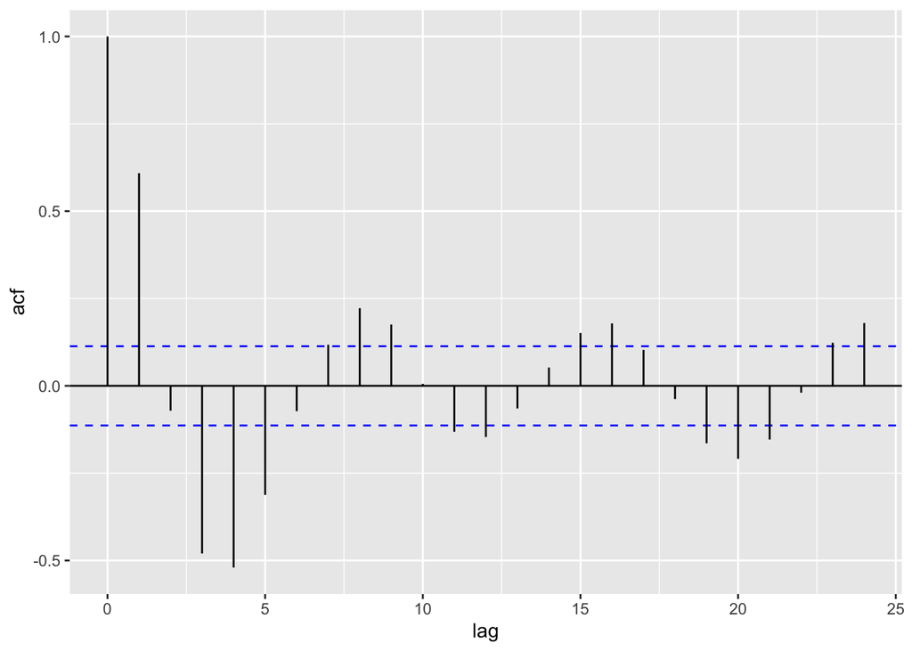

```r
conf.level <- 0.95
ciline <- qnorm((1 - conf.level)/2)/sqrt(length(data_serie[-nrow(data_serie),]$serie_diff))
bacf <- acf(data_serie[-nrow(data_serie),]$serie_diff, plot = FALSE)
bacfdf <- with(bacf, data.frame(lag, acf))

ggplot(data = bacfdf, aes(x = lag, y = acf)) +
       geom_hline(aes(yintercept = 0)) +
        geom_hline(aes(yintercept = -ciline), color = "blue", lty = 'dashed') +
        geom_hline(aes(yintercept = ciline), color = "blue", lty = 'dashed') +
       geom_segment(mapping = aes(xend = lag, yend = 0))
```

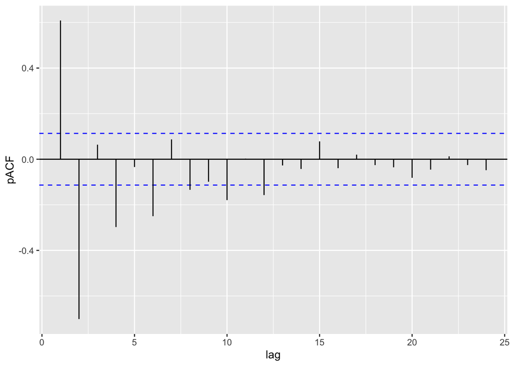

```r
conf.level <- 0.95
ciline <- qnorm((1 - conf.level)/2)/sqrt(length(data_serie[-nrow(data_serie),]$serie_diff))
bacf <- pacf(data_serie[-nrow(data_serie),]$serie_diff, plot = FALSE)
bacfdf <- with(bacf, data.frame(lag, acf))

ggplot(data = bacfdf, aes(x = lag, y = acf)) +
       geom_hline(aes(yintercept = 0)) +
        geom_hline(aes(yintercept = -ciline), color = "blue", lty = 'dashed') +
        geom_hline(aes(yintercept = ciline), color = "blue", lty = 'dashed') +
       geom_segment(mapping = aes(xend = lag, yend = 0)) +
  ylab("pACF")
```

```r
data_modele <- data.frame(AR_p=NA, MA_q=NA, AIC=NA)
for(p in 0:3)
{
  for(q in 0:3)
  {
    data_modele[nrow(data_modele)+1,] <- c(p,q,arima(data_serie$serie_diff, order = c(p,0,q))$aic)
  }
}
```

L’AIC est minimisé pour le modèle ARMA(2, 2).

4. Estimer les paramètres du modèle sélectionné.

```r
modele <- arima(data_serie$serie_diff, order = c(data_modele[which.min(data_modele$AIC),1],0,data_modele[which.min(data_modele$AIC),2]))
modele$coef
```

```
##        ar1        ar2        ma1        ma2  intercept
##  1.2178736 -0.5873433 -0.1744466 -0.8255533  0.4959954
```

Le processus s’écrit donc $X_t = 1.22 X_{t-1} + -0.59 X_{t-2} + -0.17 \epsilon_{t-1} + -0.83 \epsilon_{t-2} + \epsilon_t$ avec $\epsilon_t$ un bruit blanc.

5. Analysez les résidus.

```r
Box.test(modele$residuals, lag = 20)
```

```
##
##  Box-Pierce test
##
## data:  modele$residuals
## X-squared = 14.863, df = 20, p-value = 0.7842
```

6. Donnez une prévision pour les 20 temps suivants de la série et représentez vos prévisions.

Prévision pour le modèle ARMA

```r
pred_arma <- predict(modele, 20)$pred
```

Ne pas oublier la tendance !

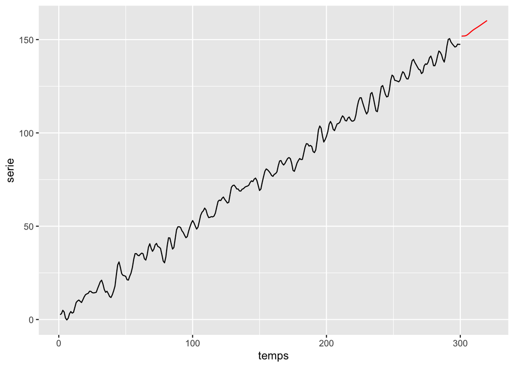

```r
A <- lm(data = data_serie, formula = serie ~ temps)

data_serie$tendance <- A$coefficients[2]*data_serie$temps + A$coefficients[1]

new_t <- (data_serie$temps[nrow(data_serie)]+1):(data_serie$temps[nrow(data_serie)]+20)
pred <- A$coefficients[2]*new_t + A$coefficients[1] + pred_arma

data_prevision <- data.frame(temps = new_t, serie = as.vector(pred), serie_diff = NA, tendance = NA, type = "prevision")
data_serie$type <- "serie"


ggplot(data_serie, aes(x = temps, y = serie)) +
    geom_line() +
    geom_line(data = data_prevision, mapping = aes(x = temps, y = serie), color = 'red')
```

# Précipitations mensuelles à San Fransisco entre 1932 et 1966

Récupérer le fichier contenant les précipitations mensuelles relevées à San Fransisco entre 1932 et 1966.

```r
datasan<-scan(file="http://math.unice.fr/~rubentha/enseignement/sanfran.dat",skip=1)
x=ts(datasan,start=c(1932,1),end=c(1966,12),frequency=12)
write(as.vector(x), file = "SanFransisco.txt", ncolumns = 1)
```

1. La série semble-t-elle stationnaire ?
2. On propose de modéliser la série avec un SARIMA(2,0,0,12). Rappelez les caractéristiques de ce modèle
3. Estimer le modèle SARIMA(2,0,0,12). Afficher et tester les résidus.
4. Prévoir les précipitations de 1964, 1965 et 1966 à partir de ce modèle et représentez les.